# Creating and formatting CVs on Overleaf (LaTeX)

Adriana Picoral

January 22, 2021

In this workshop we will select a CV LaTeX template and modify it on [Overleaf](https://www.overleaf.com/). A brief overview of what LaTeX is and its syntax will be provided. This workshop was organized by the Hispanic & Lusophone Linguistics Working Group.

# 1 What is LaTeX?

LaTeX (mainly pronounce as either /ˈlɑ.tɛk/ or /ˈleɪ.tɛk/) is a markup language. As other markup languages (e.g., HTML and markdown), LaTeX is a way to systematically annotate text so that documents are processed with the desire formatting without having to click and select different formatting options. The advantage of using markup for text formatting is that you can easily change the style of your formatting without having to change the style markup throughout your document. The idea is to separate the presentation (i.e., formatting and layout) from the content of your text (i.e., the actual words). A lot of journals offer LaTeX templates so that you guarantee you are abiding to the journals formatting style without actually having to do any formatting yourself.

In fact, Microsoft Word has a way to mark certain parts of the text as `Emphasis` or `Strong` instead of *italics* and **bold** so that you can create the semantic structure for text formatting. This helps you when you want to change what *italics* and **bold** (and other type of formatting) look like, but it also makes your document more accessible – screen readers will often reflect the emphasis or the strong formatting using different prosody for the words with semantic structure (but they won’t do so if you just use bold and italics from the formatting menu).

> Let’s check what Microsoft Word’s `style pane` does and how to apply and change a style.
1. Open Microsoft Word
2. In the `Home` tab on the top menu, click on `Styles Pane`, which will open the Styles pane to the right of your document
3. Type something and try different styles, repeating the same style throughout the text
4. Change the style by clicking on the down arrow that shows up when you hover a style on the `Styles Pane` and the selecting `Modify Style...`

LaTeX allows you to markup your text for your semantic structure without having to hunt for the right button on a graphical interface. It takes some time to be able to type in LaTeX, but once you do you can write and format (and reformat) documents much more easily.

Nowadays there are a lot of LaTeX templates available for free, so you don’t have to build your document from scratch. That is also another advantage of using LaTeX, you can create your own template and share it with others, who in turn can focus only on the content (i.e., words) of the document and not worry about the layout and formatting.

# 2 Using Overleaf

## 2.1 What is Overleaf?

Overleaf is a Google Drive for LaTeX document, e.g., it is a cloud-based LaTeX editor. Its Free plan allows you to create unlimited private projects. For collaboration, you need a paid plan. You can sign up with your university Google account, which I highly recommend since you won’t have to remember a unique password to get to your Overleaf documents.

1. Go to https://www.overleaf.com/
2. Click on `Register using Google` if you don’t have an Overleaf account or `Log In` if you do
3. Click on `New Project` and then choose `Résumé/CV`

## 2.2 Overleaf Templates

We will start by browsing [Overleaf’s extensive template library](https://www.overleaf.com/latex/templates) to look for a CV we like.

Once you found a template you like, click on it and choose `Open as Template` – this will copy the document to your Overleaf home.

## 2.3 Overleaf document parts

When you open a LaTeX document on Overleaf, you see two main panels:

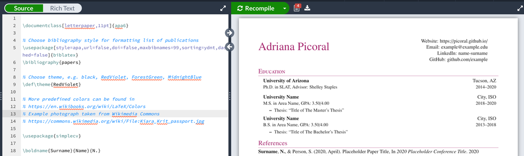

Figure 2.1: Main Overleaf panels showing the source and the compiled document side by side

You make changes to the panel on the left (i.e., `Source`) and see the compiled document on the right. You can click on the green `Recompile` button on the top of the right panel to see your changes in the output document. You can also download your compiled document in pdf format.

## 2.4 Updating your CV

Update your CV often. Every time you get a proposal accepted to a conference, or you start writing a manuscript, is a good time to update your CV.

Here are some useful LaTeX syntax:

- use % to comment out a line
- the back slash (i.e., `\`) is used for starting a tag (e.g., `\begin{document}`) and escaping special characters (e.g., `\&`)
- curly brackets (i.e., `{}`) specifies what is set by the tag
- use `\textbf{}` for **b**old **f**ont
- use `\textit{}` for **it**alics
- use `\includegraphics{filename.png}` for adding images to your document

Some terminology:

- The **preamble** of a document is everything that comes before `\begin{document}`, this is where you set the type of document, specify title (`\title{My Title}`), author (`\author{Fulando De Tal}`), load packages, etc.
- To **compile** a document is to convert the source (i.e., LaTeX file) into the output document (i.e., pdf file)

# 3 Other Resources

- [Overleaf Documentation](https://www.overleaf.com/learn/latex/Main_Page) contains a number of guides for using Overleaf and LaTeX (including info on how to use tables, figures, and bibliography)